# ML One Network: Norming Variable Power Analysis

Erin M. Buchanan

2026-07-31

## Sample Size Estimation for Subjective Rating Variables

In a follow up to the Semantic Priming Across Many Languages (Buchanan et al. 2025) project, we will collect data across 45 languages/variants on the following norming variables: familiarity, concreteness, valence, arousal, imageability, and age of acquisition (AoA). We will use the Buchanan et al. (2026) accuracy in parameter estimation procedure to determine how many participants we need to create a sufficiently narrow confidence interval around the mean for each item. In this procedure, we use the following steps (reproduced from original article):

### Step 1.

Use representative pilot data.

We included all norming datasets found in the original Linguistic Annotated Bibiolography (Buchanan et al. 2019) and the updated LAB workflow under construction at https://manynorms.many-languages.com. We included datasets with our target variables that included information about the mean and standard deviation of each item. Datasets with only the mean were excluded, as we could not simulate the data appropriately with no information about variance. The original articles were reviewed for information on item sample sizes, which was matched to the variables included in the dataset. In cases of range estimates provided in the manuscript (i.e., 15-20 people rated each item), we used the lower end of the range to estimate with less precision (which would, in turn, increase sample size requirements due to more uncertainty). The following datasets were used:

```r
dataset_variables <- read.csv("datasets_with_power_variables.csv", stringsAsFactors = FALSE)

dataset_citation_table <- dataset_variables %>%
  dplyr::mutate(
    bibtex_key = sub("\\.csv$", "", dataset),
    Reference = sprintf("[@%s]", bibtex_key),
    Variables = dplyr::case_when(
      TRUE ~ apply(
        dplyr::select(., familiar, concrete, valence, arousal, imagine, aoa), 1,
        function(row) paste(names(row)[row == "x" & !is.na(row)], collapse = ", ")
      )
    )
  ) %>%
  dplyr::transmute(Dataset = bibtex_key, Variables, Reference)

knitr::kable(dataset_citation_table, row.names = FALSE)
```

| Dataset | Variables | Reference |
| --- | --- | --- |
| Alario1999 | familiar, aoa | (Alario and Ferrand 1999) |
| Alonso2015 | aoa | (Alonso et al. 2015) |
| Alonso2016 | aoa | (Alonso et al. 2016) |
| Barca2002 | familiar, concrete, imagine, aoa | (Barca et al. 2002) |
| Bennett2011 | imagine | (Bennett et al. 2011) |
| Berrian1979 | imagine | (Berrian et al. 1979) |
| Birchenough2017 | aoa | (Birchenough et al. 2017) |
| Bogunovic2023 | familiar, concrete, valence, arousal | (Bogunović 2023) |
| Bonin2003 | familiar, aoa | (Bonin et al. 2003) |
| Bonin2018 | concrete, valence, arousal | (Bonin et al. 2018) |
| Bonin2021 | familiar, imagine, aoa | (Bonin et al. 2021) |
| Borsa2025 | familiar, concrete, valence, arousal, imagine, aoa | (Borsa et al. 2025) |
| Boukadi2016 | familiar, imagine | (Boukadi et al. 2016) |
| Bradley1999 | valence, arousal | (Bradley and Lang 1999) |
| Brysbaert2014 | concrete | (Brysbaert, Warriner, et al. 2014) |
| Brysbaert2014a | concrete, aoa | (Brysbaert, Stevens, et al. 2014) |
| Cameirao2010 | aoa | (Cameirão and Vicente 2010) |
| Carroll1973 | aoa | (Carroll and White 1973) |
| Chan2024 | familiar, concrete, valence, arousal, imagine | (Chan and Tse 2024) |
| Cheng2025 | valence, arousal | (Cheng et al. 2025) |
| Citron2016 | familiar, concrete, valence, arousal | (Citron et al. 2016) |
| Clarke2018 | familiar, aoa | (Clarke and Ludington 2018) |
| Clarke2024 | imagine, aoa | (Clarke 2024) |
| Conca2024 | familiar, valence, arousal, imagine, aoa | (Conca et al. 2024) |
| Conde2026_familiar_human | familiar | (Conde et al. 2026) |
| Cortese2004 | imagine | (Cortese and Fugett 2004) |
| Coso2019 | concrete, valence, arousal | (Ćoso et al. 2019) |
| DeDeyne2008 | familiar, imagine | (Deyne and Storms 2008) |
| DellaRosa2010 | familiar, concrete, imagine, aoa | (Rosa et al. 2010) |
| Dellacqua2000_1 | familiar, aoa | (Dell’acqua et al. 2000) |

[output cut: 91 more lines]

### Step 2.

Calculate the standard error of each of the items in the pilot data. Using the 4th decile, determine the cutoff and stopping rule for the standard error of the items.

Using the *semanticprimeR* package (Buchanan 2024), we then simulated the pilot data using the mean, standard deviation, and sample size from each dataset for the items included. This dataset was treated as the “population”, and we estimated the 4th decile standard error across all items as the cutoff score and stopping rule for the standard error of the items.

### Step 3.

Create simulated samples of your pilot data, starting with at least 20 participants, up to a maximum number of participants.

We then sampled from the simulated pilot data, from *n* = 20 up to *n* = 500. However, running the simulation over many samples by many simulations by every dataset would be extremely slow. Therefore, we broke the simulations into two stages:

1. Pilot - a coarse sweep per dataset (sample sizes 20-500, step 10, 10 simulations per step) to find roughly where the precision curve crosses 70% and 95% rates. `run_power_pilot.R`
2. Refine - a narrow, high-precision rerun (step 5, 100 simulations per step) restricted to the pilot’s recommended `[start, stop]` window for that specific dataset. `run_power_refine.R`

Both of these scripts call `run_power_batch.R` to do the simulations. This document reads the refined stage output only, since that is the higher-precision, final estimate.

### Step 4.

Calculate the standard error of each of the items in the simulated data. From these scores, calculate the percent of items below the cutoff score from Step 2.

### Step 5.

Determine the sample size at which 80%, 85%, 90%, 95% of items are below the cutoff score. Use the correction formula to adjust your proposed sample size based on pilot data size, power, and percent variability.

`functions.R` implements steps 3-5 using tools from the `semanticprimeR` package for each real dataset in `power_job_list.csv`.

### Step 6.

Report all values. Designate one as the minimum sample size, the cutoff score as the stopping rule for adaptive designs, and the maximum sample size.

### Split-half Reliability

We additionally included a calculation of split-half reliability for each of the sample sizes. Participants for each item are split in half, the two half-means are correlated, and the Spearman-Brown correction is then applied. This result tells us how consistent the item-level scores would be with a given number of raters per item. Generally, numbers can be very low and obtain reliability. We tested reliability at sample sizes of *n* = 5 to the stop of the range found for each dataset from the pilot sample size estimation steps.

## Target Criteria and Outlier Handling

We target 80% power (AIPE precision) and 80% split-half reliability, and report the recommended sample size per variable as the average of those two numbers. Precision and reliability answer different questions about the same design (how accurately measured is the estimated mean vs. how consistent are the item scores), so averaging them gives one practical number rather than always taking the stricter of the two. We tested *n* = 5, but set the bottom value for reliability to be *n* = 20. Therefore, that means even if samples achieved high reliability at *n* = 5, 10, or 15, the lowest number we would accept for the average of criterions would be *n* = 20, as otherwise the low numbers might bias the sample size estimates downward inappropriately.

Each of these numbers is computed per dataset run (i.e., per source paper/corpus) before pooling: for a given variable, every dataset run contributes one “n needed for 80% precision” value and one “n needed for 80% reliability” value. A handful of source datasets are small, noisy, or otherwise unusual and can pull these per-run numbers to extreme highs or lows. Before pooling across runs, we drop outlier runs using the standard 1.5 x IQR rule (values more than 1.5 interquartile ranges below Q1 or above Q3 are dropped), applied separately to the precision values and the reliability values for that variable. We then take the median of the remaining runs for each metric (median rather than mean, since a handful of runs can still sit near the outlier boundary without being dropped outright - in practice the two are close once outliers are trimmed, but median is the more standard choice for a “typical” recommendation). The per-variable sections below show which runs were considered outliers.

## Loading Refined Results

```r
variable_dirs <- file.path("simulations", VARIABLES, "refined")
names(variable_dirs) <- VARIABLES
available_vars <- VARIABLES[dir.exists(variable_dirs) &
  lengths(purrr::map(variable_dirs, list.files, pattern = "\\.rds$")) > 0]

cat("Variables with refined output available:", paste(available_vars, collapse = ", "), "\n")
```

```
## Variables with refined output available: familiar, concrete, valence, arousal, imagine, aoa
```

```r
cat("Variables still pending:", paste(setdiff(VARIABLES, available_vars), collapse = ", "), "\n")
```

```
## Variables still pending:
```

```r
results_by_variable <- purrr::map(
  setNames(available_vars, available_vars),
  ~ load_and_summarize_simulations(file.path("simulations", .x, "refined"))
)
```

Each dataset contributes one simulation “run” per variable (i.e., one row per source paper/corpus that reported that variable for the words in our stimuli set). The tables below pool across *all* dataset runs for a variable, since our own norming study will draw one sample of participants per item. Each of these datasets is a mix of languages, so we estimate our overall sample size globally, rather than by language.

## Per-Variable Results

```r
target_results_by_variable <- purrr::map(results_by_variable, ~ summarize_by_target(.x$overall_power))
labeled_power_by_variable <- purrr::map(results_by_variable, ~ label_by_target(.x$overall_power))
variable_recommendation <- purrr::map(results_by_variable, ~ summarize_variable_recommendation(.x))

variable_labels <- c(
  familiar = "Familiarity", concrete = "Concreteness", valence = "Valence",
  arousal = "Arousal", imagine = "Imageability", aoa = "Age of Acquisition (AoA)"
)

for (v in available_vars) {
  cat(sprintf("\n### %s\n\n", variable_labels[[v]]))

  res <- results_by_variable[[v]]
  target_summary <- target_results_by_variable[[v]]
  n_runs <- dplyr::n_distinct(res$overall_power$run_id)
  cat(sprintf("Based on %d dataset run(s) for `%s`.\n\n", n_runs, v))

  cat("**Recommended sample size per item, by target precision (% of simulations hitting the AIPE cutoff):**\n\n")
  print(htmltools::tagList(DT::datatable(
    target_summary %>%
      dplyr::mutate(dplyr::across(where(is.numeric), ~ round(.x, 2))),
    rownames = FALSE, options = list(dom = "t", pageLength = 10)
  )))

  box_dat <- labeled_power_by_variable[[v]] %>%
    dplyr::mutate(target_power = factor(target_power, levels = REFINE_POWER_LEVELS))
  print(
    ggplot2::ggplot(box_dat, ggplot2::aes(x = target_power, y = corrected_sample_size)) +
      ggplot2::geom_boxplot(fill = "#d9e7ff", outlier.alpha = 0.2, width = 0.6) +
      ggplot2::geom_jitter(width = 0.12, alpha = 0.35, size = 1.4) +
      ggplot2::geom_line(
        data = target_summary %>% dplyr::mutate(target_power = factor(target_power, levels = REFINE_POWER_LEVELS)),
        ggplot2::aes(x = target_power, y = recommended_sample_size, group = 1),
        color = "#b00020", linewidth = 0.9
      ) +
      ggplot2::geom_point(
        data = target_summary %>% dplyr::mutate(target_power = factor(target_power, levels = REFINE_POWER_LEVELS)),
        ggplot2::aes(x = target_power, y = recommended_sample_size),
        color = "#b00020", size = 2.5
      ) +
      ggplot2::labs(
        x = "Target precision (%)", y = "Corrected sample size",
        title = paste0(v, ": spread of per-dataset recommendations"),
        subtitle = "red line = across-dataset running max of the median"
      ) +
      ggplot2::theme_minimal()
  )

  if (nrow(res$reliability_summary) > 0) {
    cat("\n\n**Sample size needed to reach target split-half reliability:**\n\n")
    print(htmltools::tagList(DT::datatable(
      res$reliability_recommendation %>%
        dplyr::mutate(dplyr::across(where(is.numeric), ~ round(.x, 3))),
      rownames = FALSE, options = list(dom = "t", pageLength = 10)
    )))

    if (!is.null(res$reliability_plot)) {
      print(res$reliability_plot +
        ggplot2::labs(subtitle = paste0(v, ": median reliability curve across dataset runs")))
    }
  }

  rec <- variable_recommendation[[v]]
  cat(sprintf(
    "\n\n**Recommended n (80%% precision + 80%% reliability, IQR-trimmed medians averaged): %.1f -> %d participants/item**\n\n",
    rec$recommended_n, ceiling(rec$recommended_n)
  ))
  cat(sprintf(
    "- Precision: %.1f (median of %d/%d runs kept after IQR trim)\n",
    rec$precision_median, rec$precision_n_kept, rec$precision_n_total
  ))
  cat(sprintf(
    "- Reliability: %.1f (median of %d/%d runs kept after IQR trim)\n",
    rec$reliability_median, rec$reliability_n_kept, rec$reliability_n_total
  ))

  cat("\n\n**Per-dataset detail (n at 80% precision, n at 80% reliability, outlier flags):**\n\n")
  print(htmltools::tagList(DT::datatable(
    rec$per_run %>%
      dplyr::mutate(dplyr::across(c(n_precision, n_reliability), ~ round(.x, 1))) %>%
      dplyr::arrange(dplyr::desc(n_precision)),
    rownames = FALSE, options = list(pageLength = 10)
  )))

  cat("\n\n---\n")
}
```

### Familiarity

Based on 57 dataset run(s) for `familiar`.

**Recommended sample size per item, by target precision (% of simulations hitting the AIPE cutoff):**

| target_power | n_runs | mean_recommended_sample_size | median_recommended_sample_size | sd_recommended_sample_size | min_recommended_sample_size | max_recommended_sample_size | recommended_sample_size |
| --- | --- | --- | --- | --- | --- | --- | --- |
| 70 | 57 | 44.38 | 42.3 | 20.36 | 9.83 | 141.82 | 43 |
| 75 | 57 | 46.36 | 44.01 | 20.98 | 9.83 | 143.45 | 45 |
| 80 | 57 | 50.23 | 47.21 | 20.96 | 19.87 | 145.56 | 48 |
| 85 | 57 | 53.66 | 49.22 | 21.36 | 19.87 | 147.96 | 50 |
| 90 | 57 | 58.23 | 54.61 | 21.98 | 29.17 | 153.24 | 55 |
| 95 | 47 | 62.23 | 59.89 | 19.02 | 37.45 | 112.77 | 60 |

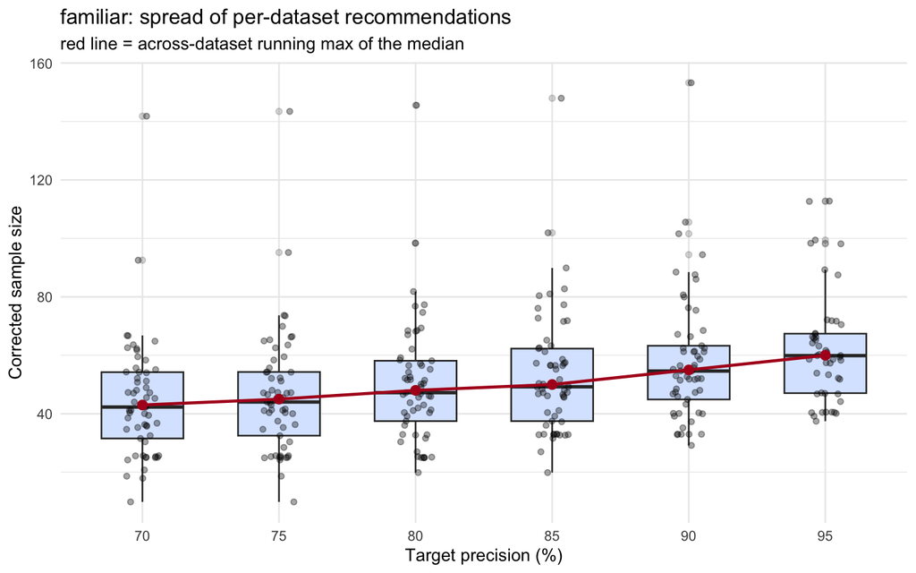

**Sample size needed to reach target split-half reliability:**

| target_reliability | recommended_sample_size | median_reliability |
| --- | --- | --- |
| 0.8 | 20 | 0.949 |
| 0.85 | 20 | 0.949 |
| 0.9 | 20 | 0.949 |
| 0.95 | 50 | 0.953 |

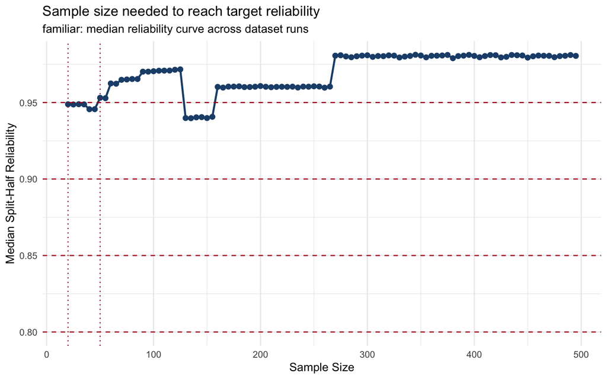

**Recommended n (80% precision + 80% reliability, IQR-trimmed medians averaged): 33.4 -> 34 participants/item**

- Precision: 46.8 (median of 55/57 runs kept after IQR trim)
- Reliability: 20.0 (median of 56/56 runs kept after IQR trim)

**Per-dataset detail (n at 80% precision, n at 80% reliability, outlier flags):**

| run_id | n_precision | n_reliability | precision_outlier | reliability_outlier |
| --- | --- | --- | --- | --- |
| Janschewitz2008 | 145.6 | 20 | True | False |
| Gilhooly1980 | 98.4 | 20 | True | False |
| Bogunovic2023 | 81.8 | 20 | False | False |
| Yao2017 | 77.3 | 20 | False | False |
| Toglia1978 | 76.8 | 20 | False | False |
| Kraljevic2018 | 74.7 | 20 | False | False |
| Navarrete2019 | 69.3 | 20 | False | False |
| Salmon2010 | 68.5 | 20 | False | False |
| Moreno-Martinez2012 | 68.4 | 20 | False | False |
| Lachaud2007 | 68.2 | 20 | False | False |

[output cut: 48 more lines]

### Concreteness

Based on 38 dataset run(s) for `concrete`.

**Recommended sample size per item, by target precision (% of simulations hitting the AIPE cutoff):**

| target_power | n_runs | mean_recommended_sample_size | median_recommended_sample_size | sd_recommended_sample_size | min_recommended_sample_size | max_recommended_sample_size | recommended_sample_size |
| --- | --- | --- | --- | --- | --- | --- | --- |
| 70 | 38 | 50.45 | 42.41 | 36.24 | 18.1 | 213.49 | 43 |
| 75 | 38 | 52.76 | 44.26 | 36.51 | 24.44 | 217.11 | 45 |
| 80 | 38 | 56.4 | 47.77 | 36.88 | 24.61 | 221.26 | 48 |
| 85 | 38 | 59.67 | 50.54 | 38.18 | 25.16 | 228.03 | 51 |
| 90 | 38 | 64.71 | 54.62 | 38.92 | 32.35 | 235.13 | 55 |
| 95 | 32 | 59.72 | 57.26 | 17.29 | 33.56 | 106.49 | 58 |

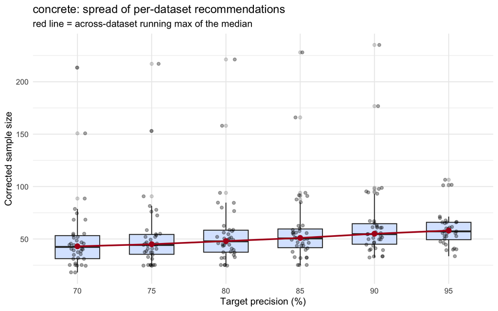

**Sample size needed to reach target split-half reliability:**

| target_reliability | recommended_sample_size | median_reliability |
| --- | --- | --- |
| 0.8 | 20 | 0.961 |
| 0.85 | 20 | 0.961 |
| 0.9 | 20 | 0.961 |
| 0.95 | 20 | 0.961 |

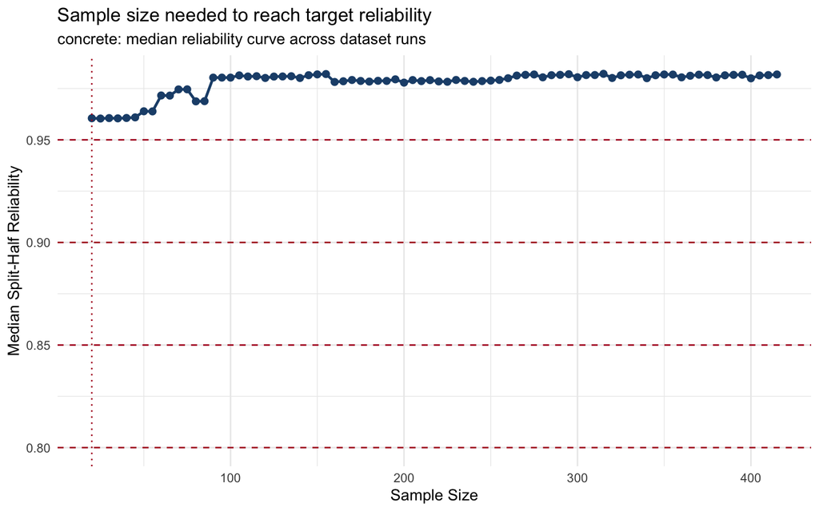

**Recommended n (80% precision + 80% reliability, IQR-trimmed medians averaged): 33.0 -> 33 participants/item**

- Precision: 45.9 (median of 35/38 runs kept after IQR trim)
- Reliability: 20.0 (median of 38/38 runs kept after IQR trim)

**Per-dataset detail (n at 80% precision, n at 80% reliability, outlier flags):**

| run_id | n_precision | n_reliability | precision_outlier | reliability_outlier |
| --- | --- | --- | --- | --- |
| Montefinese2023_en | 221.3 | 20 | True | False |
| Montefinese2023_it | 158 | 20 | True | False |
| Gilhooly1980 | 94 | 20 | True | False |
| Yao2017 | 84.7 | 20 | False | False |
| Kanske2010 | 84.5 | 20 | False | False |
| Paivio1968 | 80 | 20 | False | False |
| DellaRosa2010 | 76.7 | 20 | False | False |
| Barca2002 | 62.6 | 20 | False | False |
| Friendly1982 | 58.7 | 20 | False | False |
| Soares2017 | 58.7 | 20 | False | False |

[output cut: 28 more lines]

### Valence

Based on 41 dataset run(s) for `valence`.

**Recommended sample size per item, by target precision (% of simulations hitting the AIPE cutoff):**

| target_power | n_runs | mean_recommended_sample_size | median_recommended_sample_size | sd_recommended_sample_size | min_recommended_sample_size | max_recommended_sample_size | recommended_sample_size |
| --- | --- | --- | --- | --- | --- | --- | --- |
| 70 | 41 | 46.98 | 42.49 | 25.8 | 9.32 | 163.02 | 43 |
| 75 | 41 | 50.11 | 44.43 | 27.02 | 9.32 | 169.42 | 45 |
| 80 | 41 | 54.3 | 49.55 | 27.85 | 9.32 | 176.29 | 50 |
| 85 | 41 | 59.22 | 53.82 | 29.32 | 9.32 | 185.85 | 54 |
| 90 | 40 | 64.41 | 58.73 | 31 | 10 | 198.02 | 59 |
| 95 | 39 | 74.49 | 68.33 | 34.11 | 20.4 | 219.66 | 69 |

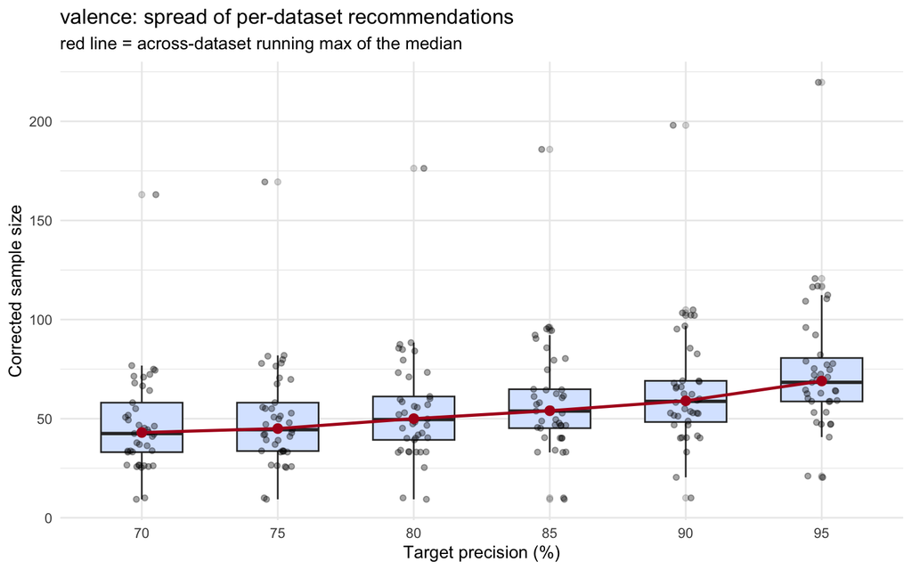

**Sample size needed to reach target split-half reliability:**

| target_reliability | recommended_sample_size | median_reliability |
| --- | --- | --- |
| 0.8 | 20 | 0.98 |
| 0.85 | 20 | 0.98 |
| 0.9 | 20 | 0.98 |
| 0.95 | 20 | 0.98 |

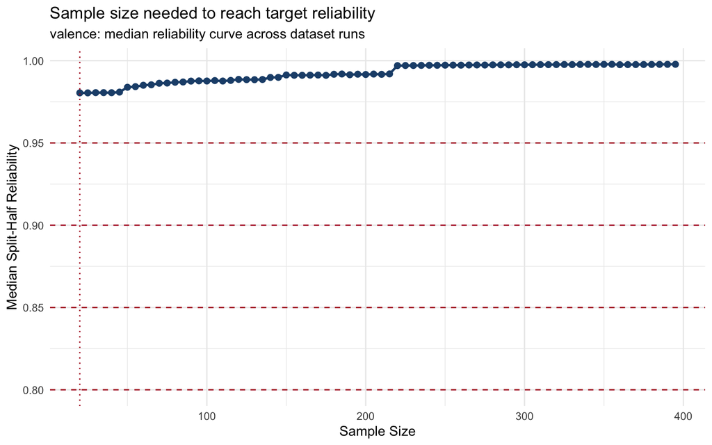

**Recommended n (80% precision + 80% reliability, IQR-trimmed medians averaged): 34.5 -> 35 participants/item**

- Precision: 48.9 (median of 40/41 runs kept after IQR trim)
- Reliability: 20.0 (median of 41/41 runs kept after IQR trim)

**Per-dataset detail (n at 80% precision, n at 80% reliability, outlier flags):**

| run_id | n_precision | n_reliability | precision_outlier | reliability_outlier |
| --- | --- | --- | --- | --- |
| Janschewitz2008 | 176.3 | 20 | True | False |
| Yao2017 | 88.3 | 20 | False | False |
| Kurdi2017 | 87.4 | 20 | False | False |
| Stadthagen-Gonzalez2017 | 85.6 | 20 | False | False |
| Raslescu2023 | 84.9 | 20 | False | False |
| Ric2013 | 84.1 | 20 | False | False |
| Roest2017 | 79.5 | 20 | False | False |
| Syssau2009 | 73.3 | 20 | False | False |
| Soares2012 | 73.2 | 20 | False | False |
| Moors2013 | 71.1 | 20 | False | False |

[output cut: 31 more lines]

### Arousal

Based on 34 dataset run(s) for `arousal`.

**Recommended sample size per item, by target precision (% of simulations hitting the AIPE cutoff):**

| target_power | n_runs | mean_recommended_sample_size | median_recommended_sample_size | sd_recommended_sample_size | min_recommended_sample_size | max_recommended_sample_size | recommended_sample_size |
| --- | --- | --- | --- | --- | --- | --- | --- |
| 70 | 34 | 40.11 | 35.21 | 26.65 | 9.42 | 162.47 | 36 |
| 75 | 34 | 41.56 | 35.47 | 27.39 | 9.42 | 166.42 | 36 |
| 80 | 34 | 43.96 | 39.58 | 27.77 | 9.42 | 170.79 | 40 |
| 85 | 34 | 46.71 | 41.31 | 28.83 | 9.42 | 175.52 | 42 |
| 90 | 34 | 50.97 | 46.03 | 29.12 | 9.42 | 180.5 | 47 |
| 95 | 34 | 55.74 | 52.17 | 30.4 | 10.66 | 190.66 | 53 |

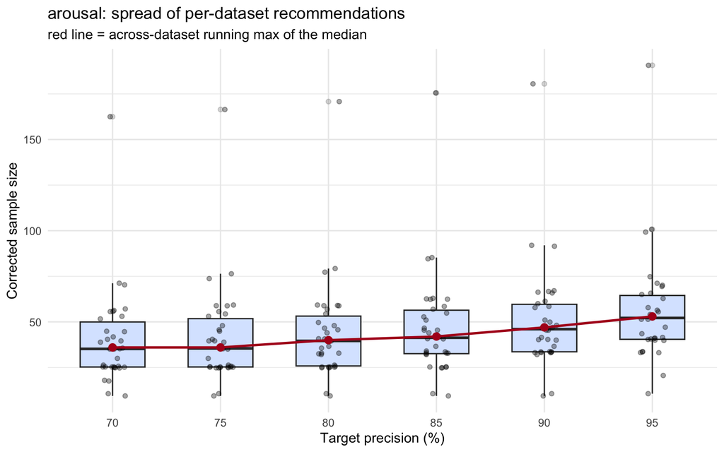

**Sample size needed to reach target split-half reliability:**

| target_reliability | recommended_sample_size | median_reliability |
| --- | --- | --- |
| 0.8 | 20 | 0.897 |
| 0.85 | 20 | 0.897 |
| 0.9 | 25 | 0.901 |
| 0.95 | 100 | 0.952 |

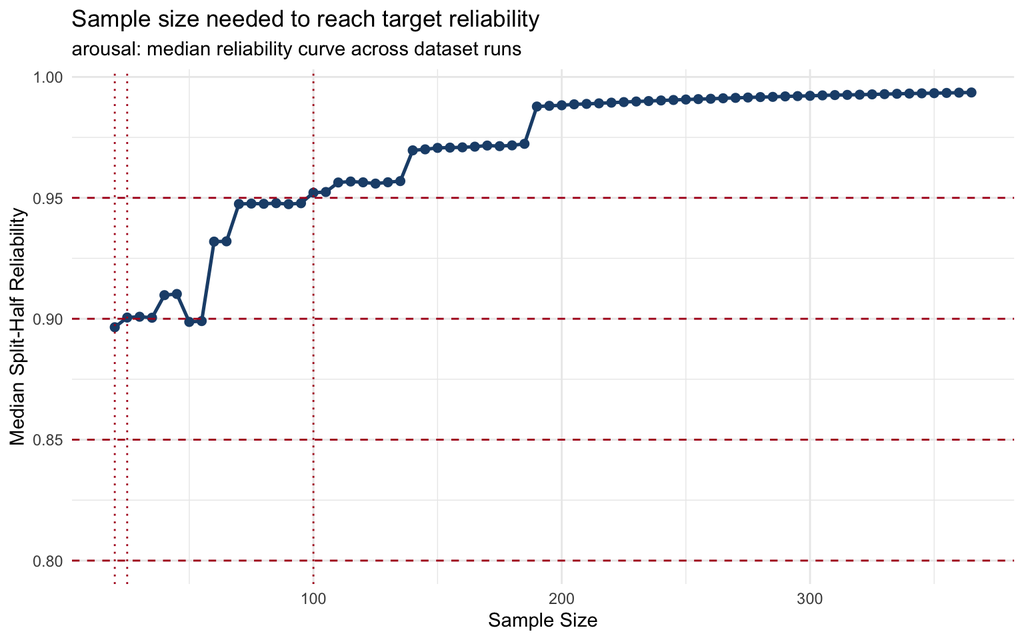

**Recommended n (80% precision + 80% reliability, IQR-trimmed medians averaged): 29.8 -> 30 participants/item**

- Precision: 39.6 (median of 33/34 runs kept after IQR trim)
- Reliability: 20.0 (median of 30/30 runs kept after IQR trim)

**Per-dataset detail (n at 80% precision, n at 80% reliability, outlier flags):**

| run_id | n_precision | n_reliability | precision_outlier | reliability_outlier |
| --- | --- | --- | --- | --- |
| Janschewitz2008 | 170.8 | 20 | True | False |
| Stadthagen-Gonzalez2017 | 79.2 | 20 | False | False |
| Yao2017 | 77.3 | 20 | False | False |
| Kurdi2017 | 59.3 | 20 | False | False |
| Moors2013 | 59 | 20 | False | False |
| Roest2017 | 58.9 | 20 | False | False |
| Kanske2010 | 58.8 | 20 | False | False |
| Soares2012 | 56.9 | 20 | False | False |
| Siew2025 | 54.4 |  | False | False |
| Schauenburg2015 | 49.7 | 20 | False | False |

[output cut: 24 more lines]

### Imageability

Based on 48 dataset run(s) for `imagine`.

**Recommended sample size per item, by target precision (% of simulations hitting the AIPE cutoff):**

| target_power | n_runs | mean_recommended_sample_size | median_recommended_sample_size | sd_recommended_sample_size | min_recommended_sample_size | max_recommended_sample_size | recommended_sample_size |
| --- | --- | --- | --- | --- | --- | --- | --- |
| 70 | 48 | 46.4 | 44.16 | 26.05 | 9.19 | 157.37 | 45 |
| 75 | 48 | 49.17 | 45.85 | 27.58 | 9.19 | 161.46 | 46 |
| 80 | 48 | 52.38 | 50 | 28.8 | 9.19 | 169.26 | 51 |
| 85 | 48 | 55.86 | 51.08 | 29.79 | 9.19 | 181.81 | 52 |
| 90 | 47 | 60.41 | 55.63 | 31.1 | 20.37 | 194.4 | 56 |
| 95 | 42 | 65.73 | 60.91 | 33.45 | 20.37 | 209.41 | 61 |

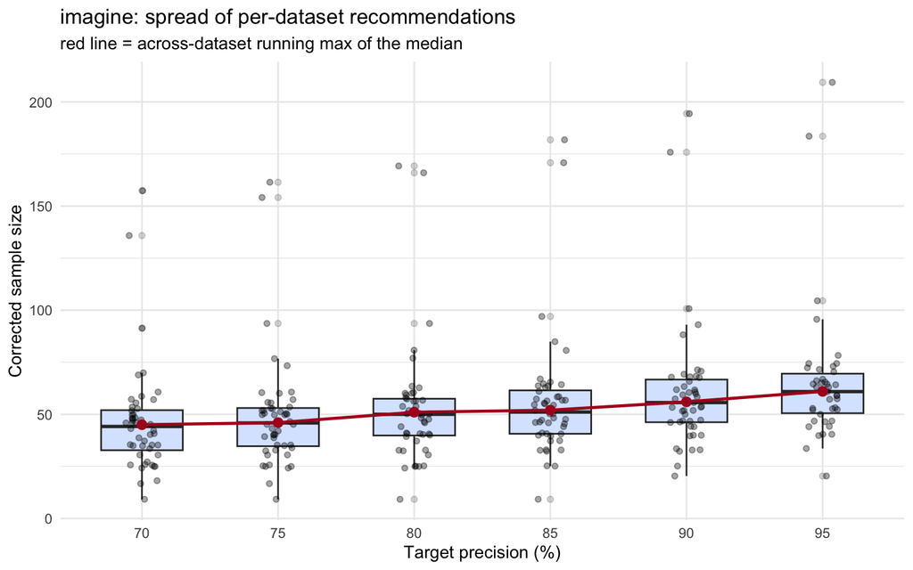

**Sample size needed to reach target split-half reliability:**

| target_reliability | recommended_sample_size | median_reliability |
| --- | --- | --- |
| 0.8 | 20 | 0.938 |
| 0.85 | 20 | 0.938 |
| 0.9 | 20 | 0.938 |
| 0.95 | 60 | 0.953 |

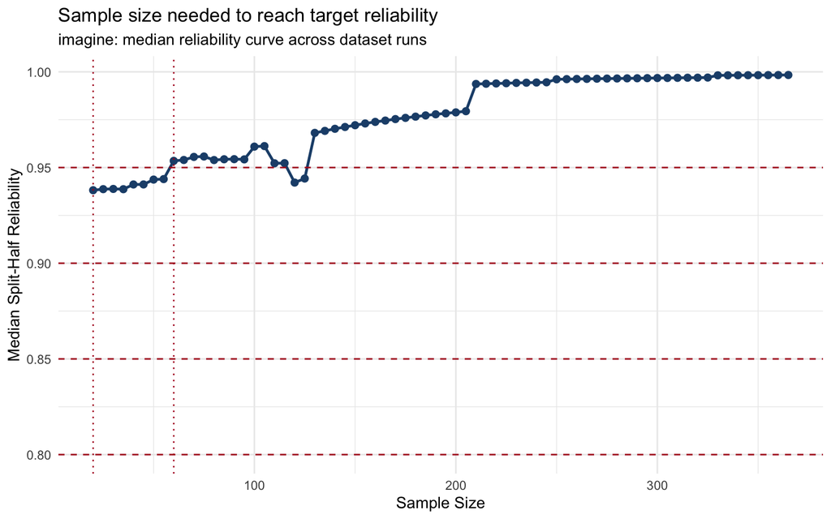

**Recommended n (80% precision + 80% reliability, IQR-trimmed medians averaged): 34.5 -> 35 participants/item**

- Precision: 49.0 (median of 44/48 runs kept after IQR trim)
- Reliability: 20.0 (median of 47/48 runs kept after IQR trim)

**Per-dataset detail (n at 80% precision, n at 80% reliability, outlier flags):**

| run_id | n_precision | n_reliability | precision_outlier | reliability_outlier |
| --- | --- | --- | --- | --- |
| Clarke2024 | 169.3 | 20 | True | False |
| Janschewitz2008 | 166 | 20 | True | False |
| Gilhooly1980 | 93.6 | 20 | True | False |
| DellaRosa2010 | 80.8 | 20 | False | False |
| Yao2017 | 77 | 20 | False | False |
| Lippman1974 | 63.5 | 20 | False | False |
| Khwaileh2018 | 62.8 | 30 | False | True |
| Berrian1979 | 60.4 | 20 | False | False |
| Desrochers2009 | 60.1 | 20 | False | False |
| Tsaparina2011 | 60.1 | 20 | False | False |

[output cut: 39 more lines]

### Age of Acquisition (AoA)

Based on 51 dataset run(s) for `aoa`.

**Recommended sample size per item, by target precision (% of simulations hitting the AIPE cutoff):**

| target_power | n_runs | mean_recommended_sample_size | median_recommended_sample_size | sd_recommended_sample_size | min_recommended_sample_size | max_recommended_sample_size | recommended_sample_size |
| --- | --- | --- | --- | --- | --- | --- | --- |
| 70 | 51 | 42.54 | 41.94 | 16.3 | 8.91 | 95.68 | 42 |
| 75 | 51 | 45.09 | 44.83 | 16.77 | 8.91 | 98.42 | 45 |
| 80 | 51 | 49.24 | 49.72 | 16.77 | 9.55 | 101.46 | 50 |
| 85 | 51 | 52.95 | 51.79 | 17.83 | 18.53 | 108.18 | 52 |
| 90 | 51 | 58.83 | 58.09 | 18.51 | 18.57 | 111.63 | 59 |
| 95 | 45 | 64 | 63.71 | 18.15 | 27.97 | 121.82 | 64 |

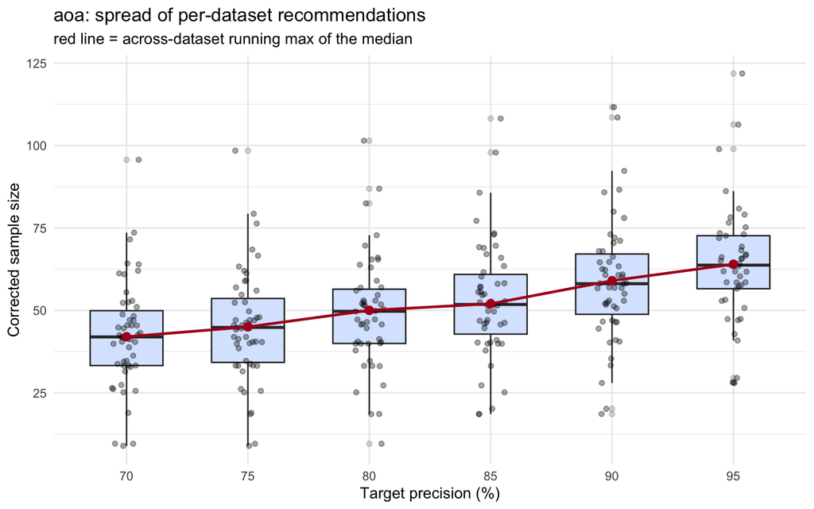

**Sample size needed to reach target split-half reliability:**

| target_reliability | recommended_sample_size | median_reliability |
| --- | --- | --- |
| 0.8 | 20 | 0.973 |
| 0.85 | 20 | 0.973 |
| 0.9 | 20 | 0.973 |
| 0.95 | 20 | 0.973 |

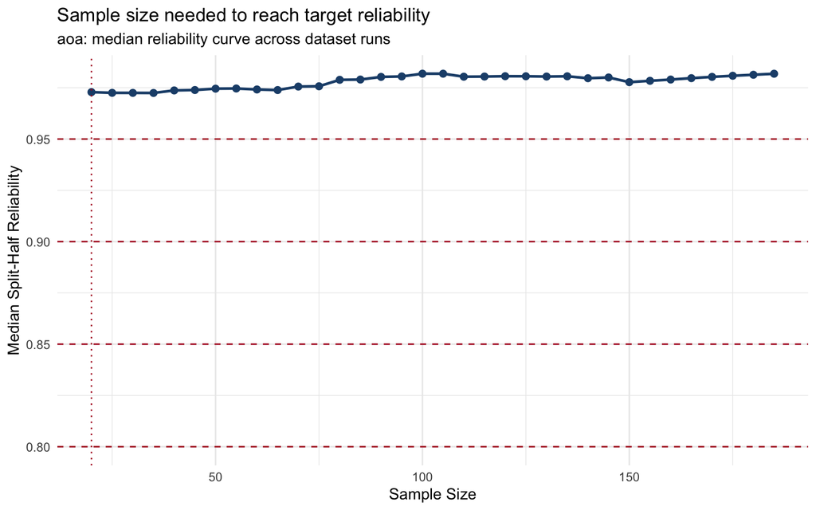

**Recommended n (80% precision + 80% reliability, IQR-trimmed medians averaged): 34.8 -> 35 participants/item**

- Precision: 49.7 (median of 47/51 runs kept after IQR trim)
- Reliability: 20.0 (median of 49/49 runs kept after IQR trim)

**Per-dataset detail (n at 80% precision, n at 80% reliability, outlier flags):**

| run_id | n_precision | n_reliability | precision_outlier | reliability_outlier |
| --- | --- | --- | --- | --- |
| Gilhooly1980 | 101.5 | 20 | True | False |
| Kraljevic2018 | 86.9 | 20 | True | False |
| Moreno-Martinez2012 | 82.5 | 20 | True | False |
| DellaRosa2010 | 72.8 | 20 | False | False |
| Navarrete2019 | 69.6 | 20 | False | False |
| Khwaileh2018 | 66 | 20 | False | False |
| Clarke2024 | 65.4 | 20 | False | False |
| Rami2022 | 65.4 | 20 | False | False |
| Lachaud2007 | 63.8 | 20 | False | False |
| Clarke2018 | 63 | 20 | False | False |

[output cut: 41 more lines]

## Combined Recommendation Across Variables

Our norming study collects all six variables from the same participants per item, so the design has to satisfy every variable’s IQR-trimmed 80/80 recommendation at once - the number is the largest `recommended_n` across variables below.

```r
combined_recommendation <- purrr::imap_dfr(variable_recommendation, function(rec, v) {
  tibble::tibble(
    variable = v,
    n_precision = rec$precision_median,
    precision_kept = sprintf("%d/%d", rec$precision_n_kept, rec$precision_n_total),
    n_reliability = rec$reliability_median,
    reliability_kept = sprintf("%d/%d", rec$reliability_n_kept, rec$reliability_n_total),
    recommended_n = rec$recommended_n
  )
})

combined_recommendation_display <- combined_recommendation %>%
  dplyr::mutate(dplyr::across(c(n_precision, n_reliability, recommended_n), ~ round(.x, 1))) %>%
  dplyr::arrange(dplyr::desc(recommended_n))

DT::datatable(combined_recommendation_display, rownames = FALSE, options = list(dom = "t", pageLength = 10))
```

| variable | n_precision | precision_kept | n_reliability | reliability_kept | recommended_n |
| --- | --- | --- | --- | --- | --- |
| aoa | 49.7 | 47/51 | 20 | 49/49 | 34.8 |
| valence | 48.9 | 40/41 | 20 | 41/41 | 34.5 |
| imagine | 49 | 44/48 | 20 | 47/48 | 34.5 |
| familiar | 46.8 | 55/57 | 20 | 56/56 | 33.4 |
| concrete | 45.9 | 35/38 | 20 | 38/38 | 33 |
| arousal | 39.6 | 33/34 | 20 | 30/30 | 29.8 |

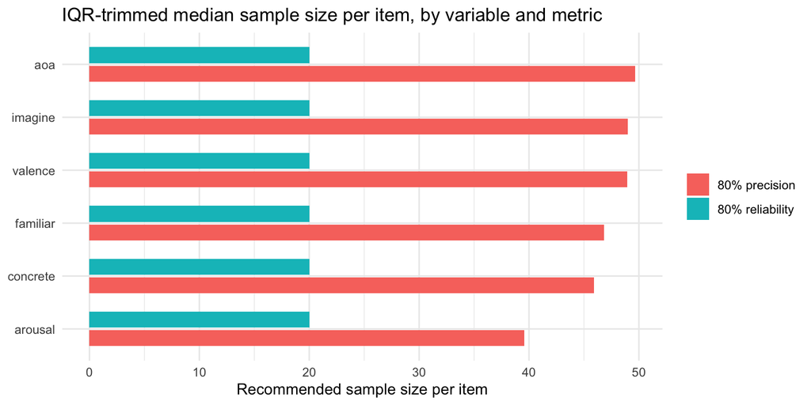

```r
plot_dat <- combined_recommendation %>%
  dplyr::select(variable, n_precision, n_reliability) %>%
  tidyr::pivot_longer(c(n_precision, n_reliability), names_to = "metric", values_to = "n") %>%
  dplyr::mutate(metric = dplyr::recode(metric, n_precision = "80% precision", n_reliability = "80% reliability"))

ggplot2::ggplot(plot_dat, ggplot2::aes(x = reorder(variable, n), y = n, fill = metric)) +
  ggplot2::geom_col(position = ggplot2::position_dodge(width = 0.7), width = 0.6) +
  ggplot2::coord_flip() +
  ggplot2::labs(
    x = NULL, y = "Recommended sample size per item",
    fill = NULL,
    title = "IQR-trimmed median sample size per item, by variable and metric"
  ) +
  ggplot2::theme_minimal()
```

```r
overall_n_needed <- max(combined_recommendation$recommended_n, na.rm = TRUE)
overall_driver <- combined_recommendation$variable[[which.max(combined_recommendation$recommended_n)]]
overall_n_needed
```

```
## [1] 34.83457
```

Bottom line: averaging 80% precision and 80% reliability (after dropping outlier dataset runs via the 1.5 x IQR rule) puts every variable’s recommended sample size at roughly 30-35 participants per item, with aoa needing the most. Our norming study needs at least 35 participants per item to satisfy every variable at once.

## References

Alario, F.-Xavier, and Ludovic Ferrand. 1999. “A Set of 400 Pictures Standardized for French: Norms for Name Agreement, Image Agreement, Familiarity, Visual Complexity, Image Variability, and Age of Acquisition.” *Behavior Research Methods, Instruments, & Computers* 31: 531–52. https://doi.org/10.3758/bf03200732.

Alonso, María Ángeles, Emiliano Díez, and Angel Fernandez. 2016. “Subjective Age-of-Acquisition Norms for 4,640 Verbs in Spanish.” *Behavior Research Methods* 48: 1337–42. https://doi.org/10.3758/s13428-015-0675-z.

Alonso, María Angeles, Angel Fernandez, and Emiliano Díez. 2015. “Subjective Age-of-Acquisition Norms for 7,039 Spanish Words.” *Behavior Research Methods* 47: 268–74. https://doi.org/10.3758/s13428-014-0454-2.

Barca, Laura, Cristina Burani, and Lisa S. Arduino. 2002. “Word Naming Times and Psycholinguistic Norms for Italian Nouns.” *Behavior Research Methods, Instruments, & Computers* 34: 424–34. https://doi.org/10.3758/bf03195471.

Bennett, Stephen D. R., A. Nicole Burnett, Paul D. Siakaluk, and Penny M. Pexman. 2011. “Imageability and Body–Object Interaction Ratings for 599 Multisyllabic Nouns.” *Behavior Research Methods* 43: 1100–1109. https://doi.org/10.3758/s13428-011-0117-5.

Berrian, Raymond W., Douglas P. Metzler, Neal E. Kroll, and Gail M. Clark-Meyers. 1979. “Estimates of Imagery, Ease of Definition, and Animateness for 328 Adjectives.” *Journal of Experimental Psychology: Human Learning and Memory* 5: 435–47. https://doi.org/10.1037/0278-7393.5.4.435.

Birchenough, Julia M. H., Robert Davies, and Vincent Connelly. 2017. “Rated Age-of-Acquisition Norms for over 3,200 German Words.” *Behavior Research Methods* 49: 484–501. https://doi.org/10.3758/s13428-016-0718-0.

Bogunović, Irena. 2023. “A Corpus-Based Approach to English Loanwords,korpusni Pristup Engleskim Posuđenicama.” *Fluminensia* 35: 437–60. https://doi.org/10.31820/f.35.2.1.

Bonin, Patrick, Betty Laroche, and Alain Méot. 2021. “Psycholinguistic Norms for a Set of 506 French Compound Words.” *Behavior Research Methods* 54: 393–413. https://doi.org/10.3758/s13428-021-01601-w.

Bonin, Patrick, Alain Méot, and Aurélia Bugaiska. 2018. “Concreteness Norms for 1,659 French Words: Relationships with Other Psycholinguistic Variables and Word Recognition Times.” *Behavior Research Methods* 50: 2366–87. https://doi.org/10.3758/s13428-018-1014-y.

Bonin, Patrick, Ronald Peereman, Nathalie Malardier, Alain Méot, and Marylène Chalard. 2003. “A New Set of 299 Pictures for Psycholinguistic Studies: French Norms for Name Agreement, Image Agreement, Conceptual Familiarity, Visual Complexity, Image Variability, Age of Acquisition, and Naming Latencies.” *Behavior Research Methods, Instruments, & Computers* 35: 158–67. https://doi.org/10.3758/bf03195507.

Borsa, Virginia Maria, Maria Arioli, Riccardo Verni, Nicola Canessa, Stefano F. Cappa, and Eleonora Catricalà. 2025. “Quantifying the Multidimensionality of Abstract Concepts: An Italian Database.” *Brain Sciences* 15: 222. https://doi.org/10.3390/brainsci15030222.

Boukadi, Mariem, Cirine Zouaidi, and Maximiliano A. Wilson. 2016. “Norms for Name Agreement, Familiarity, Subjective Frequency, and Imageability for 348 Object Names in Tunisian Arabic.” *Behavior Research Methods* 48: 585–99. https://doi.org/10.3758/s13428-015-0602-3.

Bradley, Margaret M., and Peter J. Lang. 1999. *Affective Norms for English Words (ANEW): Instruction Manual and Affective Ratings*. C-1. University of Florida, Center for Research in Psychophysiology.

Brysbaert, Marc, Michaël Stevens, Simon De Deyne, Wouter Voorspoels, and Gert Storms. 2014. “Norms of Age of Acquisition and Concreteness for 30,000 Dutch Words.” *Acta Psychologica* 150: 80–84. https://doi.org/10.1016/j.actpsy.2014.04.010.

Brysbaert, Marc, Amy Beth Warriner, and Victor Kuperman. 2014. “Concreteness Ratings for 40 Thousand Generally Known English Word Lemmas.” *Behavior Research Methods* 46: 904–11. https://doi.org/10.3758/s13428-013-0403-5.

Buchanan, Erin. 2024. *SemanticPriming/semanticprimeR: semanticprimeR Package*. [Object Object]. https://doi.org/10.5281/ZENODO.10697999.

Buchanan, Erin M., Kelly Cuccolo, Tom Heyman, et al. 2025. “Measuring the Semantic Priming Effect Across Many Languages.” *Nature Human Behaviour*, September 24, 1–20. https://doi.org/10.1038/s41562-025-02254-x.

Buchanan, Erin M., Mahmoud M. Elsherif, Jason Geller, et al. 2026. “Accuracy in Parameter Estimation and Simulation Approaches for Sample-Size Planning Accounting for Item Effects.” *Behavior Research Methods* 58 (2): 48. https://doi.org/10.3758/s13428-025-02860-7.

Buchanan, Erin M., K. D. Valentine, and Nicholas P. Maxwell. 2019. “LAB: Linguistic Annotated Bibliography a Searchable Portal for Normed Database Information.” *Behavior Research Methods* 51 (4): 1878–88. https://doi.org/10.3758/s13428-018-1130-8.

Cameirão, Manuela L., and Selene G. Vicente. 2010. “Age-of-Acquisition Norms for a Set of 1,749 Portuguese Words.” *Behavior Research Methods* 42: 474–80. https://doi.org/10.3758/brm.42.2.474.

Carroll, John B., and Margaret N. White. 1973. “Age-of-Acquisition Norms for 220 Picturable Nouns.” *Journal of Verbal Learning and Verbal Behavior* 12: 563–76. https://doi.org/10.1016/s0022-5371(73)80036-2.

Chan, Yuen-Lai, and Chi-Shing Tse. 2024. “Decoding the Essence of Two-Character Chinese Words: Unveiling Valence, Arousal, Concreteness, Familiarity, and Imageability Through Word Norming.” *Behavior Research Methods* 56: 7574–601. https://doi.org/10.3758/s13428-024-02437-w.

Cheng, Xi, Chi-Shing Tse, Yuen-Lai Chan, Kai Yan Lau, and Yen Na Yum. 2025. “Unveiling the Intensity–Ambiguity Relationships Among Affective and Lexico-Semantic Variables in Chinese Characters and the Character–Word Relationships in Chinese Two-Character Words.” *Behavior Research Methods* 57. https://doi.org/10.3758/s13428-025-02753-9.

Citron, Francesca M. M., Cristina Cacciari, Michael Kucharski, Luna Beck, Markus Conrad, and Arthur M. Jacobs. 2016. “When Emotions Are Expressed Figuratively: Psycholinguistic and Affective Norms of 619 Idioms for German (PANIG).” *Behavior Research Methods* 48: 91–111. https://doi.org/10.3758/s13428-015-0581-4.

Clarke, A. J. Benjamin, and Jason D. Ludington. 2018. “Thai Norms for Name, Image, and Category Agreement, Object Familiarity, Visual Complexity, Manipulability, and Age of Acquisition for 480 Color Photographic Objects.” *Journal of Psycholinguistic Research* 47: 607–26. https://doi.org/10.1007/s10936-017-9544-5.

Clarke, Alan James Benjamin. 2024. *TUNorms: Thai Word Norms – Imageability, Body-Object Interaction, and Subjective Frequency*. OSF. https://doi.org/10.17605/osf.io/npj4u.

Conca, Francesca, Daniela M. Gibbons, Başak Bayram, et al. 2024. “TACO: A Turkish Database for Abstract Concepts.” *Behavior Research Methods* 56: 7427–39. https://doi.org/10.3758/s13428-024-02428-x.

Conde, Javier, Gonzalo Martínez, María Grandury, et al. 2026. “Updating the German Psycholinguistic Word Toolbox with AI-Generated Estimates of Concreteness, Valence, Arousal, Age of Acquisition, and Familiarity.” *Journal of Cognition* 9. https://doi.org/10.5334/joc.482.

Cortese, Michael J., and April Fugett. 2004. “Imageability Ratings for 3,000 Monosyllabic Words.” *Behavior Research Methods, Instruments, & Computers* 36: 384–87. https://doi.org/10.3758/bf03195585.

Ćoso, Bojana, Marc Guasch, Pilar Ferré, and José Antonio Hinojosa. 2019. “Affective and Concreteness Norms for 3,022 Croatian Words.” *Quarterly Journal of Experimental Psychology* 72: 2302–12. https://doi.org/10.1177/1747021819834226.

Dell’acqua, Roberto, Lorella Lotto, and Remo Job. 2000. “Naming Times and Standardized Norms for the Italian PD/DPSS Set of 266 Pictures: Direct Comparisons with American, English, French, and Spanish Published Databases.” *Behavior Research Methods, Instruments, & Computers* 32: 588–615. https://doi.org/10.3758/bf03200832.

Desrochers, Alain, Juana M. Liceras, Raquel Fernández-Fuertes, and Glenn L. Thompson. 2010. “Subjective Frequency Norms for 330 Spanish Simple and Compound Words.” *Behavior Research Methods* 42: 109–17. https://doi.org/10.3758/brm.42.1.109.

Desrochers, Alain, and Glenn L. Thompson. 2009. “Subjective Frequency and Imageability Ratings for 3,600 French Nouns.” *Behavior Research Methods* 41: 546–57. https://doi.org/10.3758/brm.41.2.546.

Deyne, Simon De, and Gert Storms. 2008. “Word Associations: Norms for 1,424 Dutch Words in a Continuous Task.” *Behavior Research Methods* 40: 198–205. https://doi.org/10.3758/brm.40.1.198.

Díez-Álamo, Antonio M., Emiliano Díez, Dominika Zofia Wojcik, María Angeles Alonso, and Angel Fernandez. 2019. “Sensory Experience Ratings for 5,500 Spanish Words.” *Behavior Research Methods* 51: 1205–15. https://doi.org/10.3758/s13428-018-1057-0.

Falcinelli, Ilenia, Chiara Fini, Claudia Mazzuca, and Anna M. Borghi. 2024. “The TECo Database: Ecological and Technological Concepts at the Interface Between Abstractness and Concreteness.” *Collabra: Psychology* 10. https://doi.org/10.1525/collabra.120327.

Ferrand, Ludovic, Patrick Bonin, Alain Méot, et al. 2008. “Age-of-Acquisition and Subjective Frequency Estimates for All Generally Known Monosyllabic French Words and Their Relation with Other Psycholinguistic Variables.” *Behavior Research Methods* 40: 1049–54. https://doi.org/10.3758/brm.40.4.1049.

Ferré, Pilar, Marc Guasch, Cornelia Moldovan, and Rosa Sánchez-Casas. 2012. “Affective Norms for 380 Spanish Words Belonging to Three Different Semantic Categories.” *Behavior Research Methods* 44: 395–403. https://doi.org/10.3758/s13428-011-0165-x.

Fiez, J. A., and D. Tranel. 1997. “Standardized Stimuli and Procedures for Investigating the Retrieval of Lexical and Conceptual Knowledge for Actions.” *Memory & Cognition* 25: 543–69. https://doi.org/10.3758/bf03201129.

Friendly, Michael, Patricia E. Franklin, David Hoffman, and David C. Rubin. 1982. “The Toronto Word Pool: Norms for Imagery, Concreteness, Orthographic Variables, and Grammatical Usage for 1,080 Words.” *Behavior Research Methods & Instrumentation* 14: 375–99. https://doi.org/10.3758/bf03203275.

Gilhooly, K. J., and D. Hay. 1977. “Imagery, Concreteness, Age-of-Acquisition, Familiarity, and Meaningfulness Values for 205 Five-Letter Words Having Single-Solution Anagrams.” *Behavior Research Methods & Instrumentation* 9: 12–17. https://doi.org/10.3758/bf03202210.

Gilhooly, K. J., and R. H. Logie. 1980a. “Age-of-Acquisition, Imagery, Concreteness, Familiarity, and Ambiguity Measures for 1,944 Words.” *Behavior Research Methods & Instrumentation* 12: 395–427. https://doi.org/10.3758/bf03201693.

Gilhooly, K. J., and R. H. Logie. 1980b. “Meaning-Dependent Ratings of Imagery, Age of Acquisition, Familiarity, and Concreteness for 387 Ambiguous Words.” *Behavior Research Methods & Instrumentation* 12: 428–50. https://doi.org/10.3758/bf03201694.

Goten, Koen Van Der, Gino De Vooght, and Eva Kemps. 1999. “Concreteness and Emotional Valence Ratings of 399 Dutch Nouns.” *Psychologica Belgica* 39: 49. https://doi.org/10.5334/pb.941.

Granja, María Álvarez de la, María Carmen Parafita Couto, Ana Rita Sá-Leite, et al. 2025. “The Galician MultiPic: A Picture Dataset That Captures Lexical Variation.” *Frontiers in Psychology* 16. https://doi.org/10.3389/fpsyg.2025.1551000.

Grigoriev, Andrei, and Ivan Oshhepkov. 2013. “Objective Age of Acquisition Norms for a Set of 286 Words in Russian: Relationships with Other Psycholinguistic Variables.” *Behavior Research Methods* 45: 1208–17. https://doi.org/10.3758/s13428-013-0319-0.

Guasch, Marc, Pilar Ferré, and Isabel Fraga. 2016. “Spanish Norms for Affective and Lexico-Semantic Variables for 1,400 Words.” *Behavior Research Methods* 48: 1358–69. https://doi.org/10.3758/s13428-015-0684-y.

Hermans, Dirk, and Jan De Houwer. 1994. “Affective and Subjective Familiarity Ratings of 740 Dutch Words.” *Psychologica Belgica* 34: 115. https://doi.org/10.5334/pb.864.

Hinojosa, J. A., N. Martínez-García, C. Villalba-García, et al. 2016. “Affective Norms of 875 Spanish Words for Five Discrete Emotional Categories and Two Emotional Dimensions.” *Behavior Research Methods* 48: 272–84. https://doi.org/10.3758/s13428-015-0572-5.

Hinojosa, José A., Irene Rincón-Pérez, Mª Verónica Romero-Ferreiro, et al. 2016. “The Madrid Affective Database for Spanish (MADS): Ratings of Dominance, Familiarity, Subjective Age of Acquisition and Sensory Experience.” *PLOS ONE* 11: e0155866. https://doi.org/10.1371/journal.pone.0155866.

Imbir, Kamil K. 2015. “Affective Norms for 1,586 Polish Words (ANPW): Duality-of-Mind Approach.” *Behavior Research Methods* 47: 860–70. https://doi.org/10.3758/s13428-014-0509-4.

Janschewitz, Kristin. 2008. “Taboo, Emotionally Valenced, and Emotionally Neutral Word Norms.” *Behavior Research Methods* 40: 1065–74. https://doi.org/10.3758/brm.40.4.1065.

Janssen, Niels, Petra E. Pajtas, and Alfonso Caramazza. 2011. “A Set of 150 Pictures with Morphologically Complex English Compound Names: Norms for Name Agreement, Familiarity, Image Agreement, and Visual Complexity.” *Behavior Research Methods* 43: 478–90. https://doi.org/10.3758/s13428-011-0065-0.

Kanske, Philipp, and Sonja A. Kotz. 2010. “Leipzig Affective Norms for German: A Reliability Study.” *Behavior Research Methods* 42: 987–91. https://doi.org/10.3758/brm.42.4.987.

Kerr, Nancy H., and Thomas H. Johnson. 1991. “Word Norms for Blind and Sighted Subjects: Familiarity, Concreteness, Meaningfulness, Imageability, Imagery Modality, and Word Associations.” *Behavior Research Methods, Instruments, & Computers* 23: 461–85. https://doi.org/10.3758/bf03209988.

Khwaileh, Tariq, Eiman Mustafawi, Ruth Herbert, and David Howard. 2018. “Gulf Arabic Nouns and Verbs: A Standardized Set of 319 Object Pictures and 141 Action Pictures, with Predictors of Naming Latencies.” *Behavior Research Methods* 50: 2408–25. https://doi.org/10.3758/s13428-018-1019-6.

Klee, Hilary, and David Legge. 1976. “Estimates of Concreteness and Other Indices for 200 Transitive Verbs.” *Journal of Experimental Psychology: Human Learning and Memory* 2: 497–507. https://doi.org/10.1037/0278-7393.2.4.497.

Kraljević, Jelena Kuvač, and Marina Olujić. 2018. “Imageability and Subjective Frequency of the 500 Rated Nouns in the Croatian Lexical Database.” *Suvremena Lingvistika* 44: 73–90. https://doi.org/10.22210/suvlin.2018.085.04.

Kuperman, Victor, Hans Stadthagen-Gonzalez, and Marc Brysbaert. 2012. “Age-of-Acquisition Ratings for 30,000 English Words.” *Behavior Research Methods* 44: 978–90. https://doi.org/10.3758/s13428-012-0210-4.

Kurdi, Benedek, Shayn Lozano, and Mahzarin R. Banaji. 2017. “Introducing the Open Affective Standardized Image Set (OASIS).” *Behavior Research Methods* 49: 457–70. https://doi.org/10.3758/s13428-016-0715-3.

Lachaud, Christian Michel. 2007. “CHACQFAM: Une Base de Données Renseignant l’âge d’acquisition Estimé Et La Familiarité Pour 1225 Mots Monosyllabiques Et Bisyllabiques Du Français.” *L’Année Psychologique* 107: 39–63.

Li, Bing, Qiduo Lin, Hoi Yan Mak, Ovid J. L. Tzeng, Chih-Mao Huang, and Hsu-Wen Huang. 2021. “Category Exemplar Production Norms for Hong Kong Cantonese: Instance Probabilities and Word Familiarity.” *Frontiers in Psychology* 12. https://doi.org/10.3389/fpsyg.2021.657706.

Lippman, Marcia Z. 1974. “Enactive Imagery in Paired-Associate Learning.” *Memory & Cognition* 2: 385–90. https://doi.org/10.3758/bf03209014.

Liu, Jia, Lin Fan, Xiaokun Zhang, and Zeming Xu. 2026. “Affective and Psycholinguistic Norms for 1200 Two‐character Chinese Words.” *International Journal of Applied Linguistics* 36: 965–78. https://doi.org/10.1111/ijal.12829.

Manoiloff, Laura, Marcela Artstein, María Belén Canavoso, Laura Fernández, and Juan Segui. 2010. “Expanded Norms for 400 Experimental Pictures in an Argentinean Spanish-Speaking Population.” *Behavior Research Methods* 42: 452–60. https://doi.org/10.3758/brm.42.2.452.

Marques, J. Frederico, Francisca L. Fonseca, Sofia Morais, and Inês A. Pinto. 2007. “Estimated Age of Acquisition Norms for 834 Portuguese Nouns and Their Relation with Other Psycholinguistic Variables.” *Behavior Research Methods* 39: 439–44. https://doi.org/10.3758/bf03193013.

Masterson, Jackie, and Judit Druks. 1998. “Description of a Set of 164 Nounsand 102 Verbs Matched for Printed Word Frequency, Familiarityand Age-of-Acquisition.” *Journal of Neurolinguistics* 11: 331–54. https://doi.org/10.1016/s0911-6044(98)00023-2.

Miklashevsky, Alex. 2018. “Perceptual Experience Norms for 506 Russian Nouns: Modality Rating, Spatial Localization, Manipulability, Imageability and Other Variables.” *Journal of Psycholinguistic Research* 47: 641–61. https://doi.org/10.1007/s10936-017-9548-1.

Mochizuki, Masaya, and Naoto Ota. 2025. “Collection of Age of Acquisition Ratings for over 5,000 Japanese Words.” *Frontiers in Language Sciences* 4. https://doi.org/10.3389/flang.2025.1605224.

Monnier, Catherine, and Arielle Syssau. 2017. “Affective Norms for 720 French Words Rated by Children and Adolescents (FANchild).” *Behavior Research Methods* 49: 1882–93. https://doi.org/10.3758/s13428-016-0831-0.

Montefinese, Maria. 2019. “Semantic Representation of Abstract and Concrete Words: A Minireview of Neural Evidence.” *Journal of Neurophysiology* 121: 1585–87. https://doi.org/10.1152/jn.00065.2019.

Montefinese, Maria, Ettore Ambrosini, Beth Fairfield, and Nicola Mammarella. 2014. “The Adaptation of the Affective Norms for English Words (ANEW) for Italian.” *Behavior Research Methods* 46: 887–903. https://doi.org/10.3758/s13428-013-0405-3.

Montefinese, Maria, Lorenzo Gregori, Andrea Amelio Ravelli, Rossella Varvara, and Daniele Paolo Radicioni. 2023a. “CONcreTEXT Norms: Concreteness Ratings for Italian and English Words in Context.” *PLOS ONE* 18: e0293031. https://doi.org/10.1371/journal.pone.0293031.

Montefinese, Maria, Lorenzo Gregori, Andrea Amelio Ravelli, Rossella Varvara, and Daniele Paolo Radicioni. 2023b. “CONcreTEXT Norms: Concreteness Ratings for Italian and English Words in Context.” *PLOS ONE* 18: e0293031. https://doi.org/10.1371/journal.pone.0293031.

Moors, Agnes, Jan De Houwer, Dirk Hermans, et al. 2013. “Norms of Valence, Arousal, Dominance, and Age of Acquisition for 4,300 Dutch Words.” *Behavior Research Methods* 45: 169–77. https://doi.org/10.3758/s13428-012-0243-8.

Moreno-Martínez, F. Javier, Pedro R. Montoro, and Inmaculada C. Rodríguez-Rojo. 2014. “Spanish Norms for Age of Acquisition, Concept Familiarity, Lexical Frequency, Manipulability, Typicality, and Other Variables for 820 Words from 14 Living/Nonliving Concepts.” *Behavior Research Methods* 46: 1088–97. https://doi.org/10.3758/s13428-013-0435-x.

Moreno-Martínez, Francisco Javier, and Pedro R. Montoro. 2012. “An Ecological Alternative to Snodgrass & Vanderwart: 360 High Quality Colour Images with Norms for Seven Psycholinguistic Variables.” *PLoS ONE* 7: e37527. https://doi.org/10.1371/journal.pone.0037527.

Muraki, Emiko J., and Penny M. Pexman. 2025. “English Verbs Semantic Norms Database: Concreteness, Embodiment, Imageability, Valence and Arousal Ratings for 3,500 Verbs.” *Behavior Research Methods* 57. https://doi.org/10.3758/s13428-025-02675-6.

Navarrete, Eduardo, Giorgio Arcara, Sara Mondini, and Barbara Penolazzi. 2019. “Italian Norms and Naming Latencies for 357 High Quality Color Images.” *PLOS ONE* 14: e0209524. https://doi.org/10.1371/journal.pone.0209524.

Paivio, Allan, John C. Yuille, and Stephen A. Madigan. 1968. “Concreteness, Imagery, and Meaningfulness Values for 925 Nouns.” *Journal of Experimental Psychology* 76: 1–25. https://doi.org/10.1037/h0025327.

Peti-Stantić, Anita, Maja Anđel, Vedrana Gnjidić, et al. 2021. “The Croatian Psycholinguistic Database: Estimates for 6000 Nouns, Verbs, Adjectives and Adverbs.” *Behavior Research Methods* 53: 1799–816. https://doi.org/10.3758/s13428-020-01533-x.

Quadflieg, Susanne, Caroline Michel, Henryk Bukowski, and Dana Samson. 2014. “A Database of Psycholinguistic and Lexical Properties for French Adjectives Referring to Human and/or Nonhuman Attributes.” *Canadian Journal of Experimental Psychology / Revue Canadienne de Psychologie Expérimentale* 68: 67–76. https://doi.org/10.1037/cep0000001.

Raman, Ilhan, Evren Raman, and Biran Mertan. 2014. “A Standardized Set of 260 Pictures for Turkish: Norms of Name and Image Agreement, Age of Acquisition, Visual Complexity, and Conceptual Familiarity.” *Behavior Research Methods* 46: 588–95. https://doi.org/10.3758/s13428-013-0376-4.

Rami, Youssef, Samir Diouny, Mohamed Yeou, and Najib Kissani. 2024. “The Adaptation of the Object and Action Naming Battery into Moroccan Arabic: Norms for Name Agreement, Frequency, Imageability, Visual Complexity, and Age of Acquisition.” *Applied Neuropsychology: Adult* 31: 923–31. https://doi.org/10.1080/23279095.2022.2089041.

Raslescu, Andreea, Sophie Kreicker, Amy L Gillespie, William Berners-Lee, Susannah E Murphy, and Catherine J Harmer. 2023. “Positive and Negative Personality Descriptors: UK Dataset of Self-Referential Valence, Imageability and Subjective Frequency Ratings of 300 Adjectives for Use in Cognitive-Emotional Tasks.” *Data in Brief* 46: 108831. https://doi.org/10.1016/j.dib.2022.108831.

Ric, François, Theodore Alexopoulos, Dominique Muller, and Benoîte Aubé. 2013. “Emotional Norms for 524 French Personality Trait Words.” *Behavior Research Methods* 45: 414–21. https://doi.org/10.3758/s13428-012-0276-z.

Rinaldi, Pasquale, Laura Barca, and Cristina Burani. 2004. “A Database for Semantic, Grammatical, and Frequency Properties of the First Words Acquired by Italian Children.” *Behavior Research Methods, Instruments, & Computers* 36: 525–30. https://doi.org/10.3758/bf03195599.

Rocklage, Matthew D., Derek D. Rucker, and Loran F. Nordgren. 2018. “The Evaluative Lexicon 2.0: The Measurement of Emotionality, Extremity, and Valence in Language.” *Behavior Research Methods* 50: 1327–44. https://doi.org/10.3758/s13428-017-0975-6.

Roest, Sander A., Tessa A. Visser, and René Zeelenberg. 2018. “Dutch Taboo Norms.” *Behavior Research Methods* 50: 630–41. https://doi.org/10.3758/s13428-017-0890-x.

Rogić, Maja, Ana Jerončić, Marija Bošnjak, Ana Sedlar, Darko Hren, and Vedran Deletis. 2013. “A Visual Object Naming Task Standardized for the Croatian Language: A Tool for Research and Clinical Practice.” *Behavior Research Methods* 45: 1144–58. https://doi.org/10.3758/s13428-012-0308-8.

Rosa, Pasquale A. Della, Eleonora Catricalà, Gabriella Vigliocco, and Stefano F. Cappa. 2010. “Beyond the Abstract—Concrete Dichotomy: Mode of Acquisition, Concreteness, Imageability, Familiarity, Age of Acquisition, Context Availability, and Abstractness Norms for a Set of 417 Italian Words.” *Behavior Research Methods* 42: 1042–48. https://doi.org/10.3758/brm.42.4.1042.

Russell, Wallace A. 1970. “THE COMPLETE GERMAN LANGUAGE NORMS FOR RESPONSES TO 100 WORDS FROM THE KENT-ROSANOFF WORD ASSOCIATION TEST11The Work Reported Here Was Carried Out During the Writer’s Tenure as a Senior Research Scholar at the University of Wuerzburg Under a United States Government Grant (Fulbright Act). Appreciation Must Be Expressed for the Cooperation Given by Dr. W. Arnold, Head of the Psychological Institute at Wuerzburg. The Assistance of Oskar r. Meseck at All Stages of Data Collection Is Also Acknowledged, as Is the Invaluable Aid of Drs. Erwin Roth, Klaus Foppa, and Ferdinand Merz, Particularly Pertaining to Translation of English into German.” *Norms of Word Association*, 53–94. https://doi.org/10.1016/b978-0-12-563050-4.50006-6.

Ruts, Wim, Simon De Deyne, Eef Ameel, Wolf Vanpaemel, Timothy Verbeemen, and Gert Storms. 2004. “Dutch Norm Data for 13 Semantic Categories and 338 Exemplars.” *Behavior Research Methods, Instruments, & Computers* 36: 506–15. https://doi.org/10.3758/bf03195597.

Salmon, J. P., P. A. McMullen, and J. H. Filliter. 2010. “Norms for Two Types of Manipulability (Graspability and Functional Usage), Familiarity, and Age of Acquisition for 320 Photographs of Objects.” *Behavior Research Methods* 42: 82–95. https://doi.org/10.3758/brm.42.1.82.

Schauenburg, Gesche, Jens Ambrasat, Tobias Schröder, Christian von Scheve, and Markus Conrad. 2015. “Emotional Connotations of Words Related to Authority and Community.” *Behavior Research Methods* 47: 720–35. https://doi.org/10.3758/s13428-014-0494-7.

Schmidtke, David S., Tobias Schröder, Arthur M. Jacobs, and Markus Conrad. 2014. “ANGST: Affective Norms for German Sentiment Terms, Derived from the Affective Norms for English Words.” *Behavior Research Methods* 46: 1108–18. https://doi.org/10.3758/s13428-013-0426-y.

Schock, Jocelyn, Michael J. Cortese, Maya M. Khanna, and Sean Toppi. 2012. “Age of Acquisition Estimates for 3,000 Disyllabic Words.” *Behavior Research Methods* 44: 971–77. https://doi.org/10.3758/s13428-012-0209-x.

Schröder, Astrid, Teresa Gemballa, Steffie Ruppin, and Isabell Wartenburger. 2012. “German Norms for Semantic Typicality, Age of Acquisition, and Concept Familiarity.” *Behavior Research Methods* 44: 380–94. https://doi.org/10.3758/s13428-011-0164-y.

Schwitter, Valérie, Bruno Boyer, Alain Méot, Patrick Bonin, and Marina Laganaro. 2004. “French Normative Data and Naming Times for Action Pictures.” *Behavior Research Methods, Instruments, & Computers* 36: 564–76. https://doi.org/10.3758/bf03195603.

Scott, Graham G., Anne Keitel, Marc Becirspahic, Bo Yao, and Sara C. Sereno. 2019a. “The Glasgow Norms: Ratings of 5,500 Words on Nine Scales.” *Behavior Research Methods* 51: 1258–70. https://doi.org/10.3758/s13428-018-1099-3.

Scott, Graham G., Anne Keitel, Marc Becirspahic, Bo Yao, and Sara C. Sereno. 2019b. “The Glasgow Norms: Ratings of 5,500 Words on Nine Scales.” *Behavior Research Methods* 51: 1258–70. https://doi.org/10.3758/s13428-018-1099-3.

Siew, Cynthia S. Q., Feria Chang, and Jin Jye Wong. 2025. “Investigating the Effects of Valence, Arousal, Concreteness, and Humor on Words Unique to Singapore English.” *Journal of Cognition* 8. https://doi.org/10.5334/joc.470.

Snodgrass, Joan G., and Mary Vanderwart. 1980. “A Standardized Set of 260 Pictures: Norms for Name Agreement, Image Agreement, Familiarity, and Visual Complexity.” *Journal of Experimental Psychology: Human Learning and Memory* 6: 174–215. https://doi.org/10.1037/0278-7393.6.2.174.

Soares, Ana Paula, Montserrat Comesaña, Ana P. Pinheiro, Alberto Simões, and Carla Sofia Frade. 2012. “The Adaptation of the Affective Norms for English Words (ANEW) for European Portuguese.” *Behavior Research Methods* 44: 256–69. https://doi.org/10.3758/s13428-011-0131-7.

Soares, Ana Paula, Ana Santos Costa, João Machado, Montserrat Comesaña, and Helena Mendes Oliveira. 2017. “The Minho Word Pool: Norms for Imageability, Concreteness, and Subjective Frequency for 3,800 Portuguese Words.” *Behavior Research Methods* 49: 1065–81. https://doi.org/10.3758/s13428-016-0767-4.

Stadthagen-Gonzalez, Hans, Constance Imbault, Miguel A. Pérez Sánchez, and Marc Brysbaert. 2017. “Norms of Valence and Arousal for 14,031 Spanish Words.” *Behavior Research Methods* 49: 111–23. https://doi.org/10.3758/s13428-015-0700-2.

Stadthagen-González, Hans, Pilar Ferré, Miguel A. Pérez-Sánchez, Constance Imbault, and José Antonio Hinojosa. 2018. “Norms for 10,491 Spanish Words for Five Discrete Emotions: Happiness, Disgust, Anger, Fear, and Sadness.” *Behavior Research Methods* 50: 1943–52. https://doi.org/10.3758/s13428-017-0962-y.

Stration, R. Paul, Kenneth A. Jacobus, and Bonnie Brinley. 1975. “Age-of-Acquisition, Imagery, Familiarity and Meaningfulness Norms for 543 Words.” *Behavior Research Methods & Instrumentation* 7: 1–6. https://doi.org/10.3758/bf03201278.

Surprenant, Aimée M., Susan L. Hura, Mary P. Harper, et al. 1999. “Familiarity and Pronounceability of Nouns and Names.” *Behavior Research Methods, Instruments, & Computers* 31: 638–49. https://doi.org/10.3758/bf03200740.

Syssau, Arielle, and Catherine Monnier. 2009. “Children’s Emotional Norms for 600 French Words.” *Behavior Research Methods* 41: 213–19. https://doi.org/10.3758/brm.41.1.213.

Tabossi, Patrizia, Lisa Arduino, and Rachele Fanari. 2011. “Descriptive Norms for 245 Italian Idiomatic Expressions.” *Behavior Research Methods* 43: 110–23. https://doi.org/10.3758/s13428-010-0018-z.

Toglia, Michael P. 2009. “Withstanding the Test of Time: The 1978 Semantic Word Norms.” *Behavior Research Methods* 41: 531–33. https://doi.org/10.3758/brm.41.2.531.

Tsaparina, Diana, Patrick Bonin, and Alain Méot. 2011. “Russian Norms for Name Agreement, Image Agreement for the Colorized Version of the Snodgrass and Vanderwart Pictures and Age of Acquisition, Conceptual Familiarity, and Imageability Scores for Modal Object Names.” *Behavior Research Methods* 43: 1085–99. https://doi.org/10.3758/s13428-011-0121-9.

Valueva, Ekaterina, and Andrei Grigoriev. 2025. *Subjective Age of Acquisition Norms for 30,849 Russian Words*. OSF.

Verheyen, Steven, Simon De Deyne, Sarah Linsen, and Gert Storms. 2020. “Lexicosemantic, Affective, and Distributional Norms for 1,000 Dutch Adjectives.” *Behavior Research Methods* 52: 1108–21. https://doi.org/10.3758/s13428-019-01303-4.

Võ, Melissa L. H., Markus Conrad, Lars Kuchinke, Karolina Urton, Markus J. Hofmann, and Arthur M. Jacobs. 2009. “The Berlin Affective Word List Reloaded (BAWL-r).” *Behavior Research Methods* 41: 534–38. https://doi.org/10.3758/brm.41.2.534.

Walker, Howard J. 1970. “Imagery Ratings for 338 Nouns.” *Behavior Research Methods & Instrumentation* 2: 165–67. https://doi.org/10.3758/bf03209293.

Walley, Amanda C., and Jamie L. Metsala. 1992. “Young Children’s Age-of-Acquisition Estimates for Spoken Words.” *Memory & Cognition* 20: 171–82. https://doi.org/10.3758/bf03197166.

Warriner, Amy Beth, Victor Kuperman, and Marc Brysbaert. 2013. “Norms of Valence, Arousal, and Dominance for 13,915 English Lemmas.” *Behavior Research Methods* 45: 1191–207. https://doi.org/10.3758/s13428-012-0314-x.

Whalen, D. H., and Elizabeth C. Zsiga. 1994. “Subjective Familiarity of English Word/Name Homophones.” *Behavior Research Methods, Instruments, & Computers* 26: 402–8. https://doi.org/10.3758/bf03204656.

Xu, Xu, Jiayin Li, and Shulun Guo. 2021. “Age of Acquisition Ratings for 19,716 Simplified Chinese Words.” *Behavior Research Methods* 53: 558–73. https://doi.org/10.3758/s13428-020-01455-8.

Yao, Zhao, Jia Wu, Yanyan Zhang, and Zhenhong Wang. 2017. “Norms of Valence, Arousal, Concreteness, Familiarity, Imageability, and Context Availability for 1,100 Chinese Words.” *Behavior Research Methods* 49: 1374–85. https://doi.org/10.3758/s13428-016-0793-2.

Yee, Lydia T. S. 2017. “Valence, Arousal, Familiarity, Concreteness, and Imageability Ratings for 292 Two-Character Chinese Nouns in Cantonese Speakers in Hong Kong.” *PLOS ONE* 12: e0174569. https://doi.org/10.1371/journal.pone.0174569.

Yoon, Carolyn, Fred Feinberg, Ting Luo, et al. 2004. “A Cross-Culturally Standardized Set of Pictures for Younger and Older Adults: American and Chinese Norms for Name Agreement, Concept Agreement, and Familiarity.” *Behavior Research Methods, Instruments, & Computers* 36: 639–49. https://doi.org/10.3758/bf03206545.